# SPS 506 · Class 9 · Analyzing and Reporting Data

## Analyzing and Reporting Data

SPS 506 · Public Program Evaluation · October 29, 2026

Analyzing and  
Reporting Data

Handbook ch. 23, 27, and 28 · Team Read (B)

## Sampling

Part 1 · Using statistics · Newcomer and Conger, ch. 23

Sampling

Using a sample to learn about a population

## Sampling: Defining the Population

Population

A collection of things we’re interested in studying (the unit of analysis)

Population parameter (*p*)

Something we want to know about the population

| Population | Parameter |
| --- | --- |
| Team Read’s student readers | Share meeting the state reading standard |
| Idaho state employees | Share who telework at least one day a week |
| Households in Ada County | Median household income |

## Counting the Population

**Census**Count every single thing in the whole populationThe decennial census tries to count every U.S. resident

**Sample**Select parts of the population and count thoseThe American Community Survey samples about 3.5 million addresses a year

## Measure the Sample

p**Population parameter**The value we want to know. Usually we can’t measure it directly.

p̂**Sample statistic (“p-hat”)**The same quantity, measured in the sample. It is our estimate of *p*.

The hat (^) marks an estimate

## Sampling: Three Steps

Step 1**Define the population**All people or items (the unit of analysis) with the characteristics you want to study

Step 2**Choose a sampling frame**An accessible list of the population, usually with contact information, that the sample is drawn from

Step 3**Select a sample**Choose which units from the frame you will measure

Ch. 23 (p. 600): “The population of interest must be reasonably known and identifiable”

## Is the Sample Good?

**Representativeness**Does the sample look like the population?

**Bias and randomness**Does every part of the population have the same chance of being sampled?

**Generalizability**Is p̂ a good guess of *p*?

## Sampling Is a Powerful Tool

Random samples center on the true value, and larger samples land closer to it.

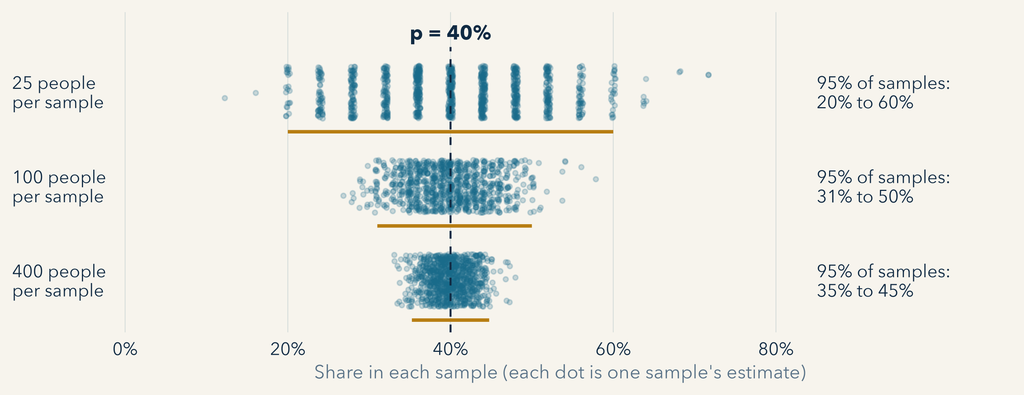

Simulated: 1,000 random samples at each size from a population where the true share is 40%

## Sampling Techniques

Probability sampling

Every unit in the population has a known, non-zero chance of being selected, and selection is random at some point.

- **Random:** draw units with random numbers
- **Systematic:** take every *n*th unit
- **Stratified:** sample randomly within subgroups

Non-probability sampling

Some units have no chance of being selected, or the chance can’t be known.

- **Convenience:** whoever is easy to reach
- **Quota:** fill set numbers per group
- **Volunteers:** people who opt in

Problems with bias and generalizability

Ch. 23, p. 601: without probability sampling, “statistics should not be generalized from the sample to the population”

## Hypothesis Testing

Part 2 · Using statistics · ch. 23

Hypothesis Testing

Using sample data to test a statement about the population

## Specifying Hypotheses

H<sub>0</sub>

**The null hypothesis:** a statement of no difference or no effect

H<sub>1</sub>

**The alternative (research) hypothesis:** a statement that there is a difference or effect

Ch. 23’s example (p. 602) H<sub>0</sub>: “Access to home health aides does not affect medical costs for emergency care.”

## Example Hypotheses

H<sub>0</sub>

There is no difference in rearrest rates within 12 months of release between prisoners released to a halfway house six months early and prisoners who served their full sentence.

H<sub>1</sub>

Prisoners released to a halfway house six months early are less likely to be rearrested within 12 months than prisoners who served their full sentence.

Based on ch. 23, Table 23A.1, p. 626

## Statistical Significance

Statistically significant

Enough evidence to safely reject the null hypothesis

p-value

The probability of observing an effect at least as large as the one found, when no effect exists

Decision rule

The usual standard is a 95% confidence level: reject H<sub>0</sub> when the p-value is below .05

At 95%: “One would obtain findings like this only five times out of one hundred samples if the null hypothesis (of no effect) was really true.” Newcomer and Conger, ch. 23, p. 604

## Statistical Significance: The Court Analogy

In a court of law

In an evaluation

The defendant is presumed innocent

H<sub>0</sub>: the program has no effect

The prosecution presents evidence

The data from the sample

Guilty beyond a reasonable doubt

Reject H<sub>0</sub>: the effect is statistically significant

Not guilty: not enough evidence to prove guilt

Fail to reject H<sub>0</sub>: not enough evidence of an effect

Ch. 23, p. 602: when the null is not rejected, “the sample data do not permit the evaluator to conclude that the program had the intended effect”

## Type I and Type II Errors

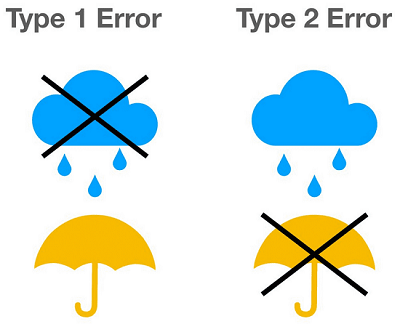

H<sub>0</sub> is trueNo real effect

H<sub>0</sub> is falseA real effect

Reject H<sub>0</sub>

**Type I error**False positive: detect an effect that is not there

Correct

Fail to reject H<sub>0</sub>

Correct

**Type II error**False negative: miss an effect that is there

Rows: what the test decides. Columns: what is actually true.

Court of law: a Type I error convicts an innocent defendant; a Type II error lets a guilty one go

## Reducing Type I and Type II Errors

Raise the standard of evidence

From 95% to 99% confidence

- Fewer false positives (Type I)
- More false negatives (Type II)

Lower the standard of evidence

From 95% to 90%, or even 80%

- Fewer false negatives (Type II)
- More false positives (Type I)
- Smaller samples needed, so lower cost

The two errors trade off. A larger sample raises **statistical power** (the ability to detect a real effect) without adding false positives.

Ch. 23, pp. 603–604

## False Positives and False Negatives in Evaluation Design

More likely to produce a false positive

- The sample is made up of volunteers
- The same instrument is used at pretest and posttest
- Only the more motivated participants stay to be measured
- Participants know they are measured and change their behavior in the desired direction (Hawthorne effect)
- The program is new, and staff or participants are extra motivated

More likely to produce a false negative

- The sample size is too small
- The time period for measurement is too short
- The program is not fully implemented
- The comparison group gets “treatment” from other sources
- Comparison group members try to make up for missing treatment, or staff give them extra help

Ch. 23, Table 23.2, p. 603

## What Are the Stakes?

**After-school reading program**Improving reading scores

**Traffic-safety regulations**Reducing accidents

**Clinical trial of a drug to treat Alzheimer’s**

Ch. 23, p. 602: “the costs of committing each should be considered and attention paid to avoiding the more costly one”

## Statistical and Practical Significance

**A tiny effect can be significant**“Will policymakers care if a new program raises third graders’ reading scores by 0.2 percent? Probably not; it is too small a gain if the program is at all costly.”Very large samples can make tiny differences statistically significant

**Report the size, with a range**“The proportion of clients still receiving welfare benefits was 5 to 10 percentage points lower for those who had completed the job training program compared to those who did not complete the training.”A confidence interval gives the size of the effect and the uncertainty around it

Ch. 23, p. 605

## Writing for Impact

Part 3 · Reporting · ch. 23, 27, and 28

Writing for Impact

Presenting numbers, making recommendations, and writing the summary

## Tips for Presenting Data Analyses

**Identify contents clearly**Use the title to identify the variables or measures used

**Mean or median?**If you write “average,” say which one you mean

**Give the sample size**For each variable in a table or figure

**Use the right base**“85 percent of the treatment group scored high on the criterion,” not “32 percent of those scoring high were in the treatment group”

**Effect size**Comment on how large the effect is as well as whether it is statistically significant

**Graphs**Start axes at zero, label lines directly instead of using a legend, and use no more than four colors

Ch. 23, Box 23.2, pp. 617–619

## Recommendations, Suggestions, and Options

Recommendations that solve problems

- Ideally, eliminate the causes of the problems in the findings
- If that isn’t possible, alleviate the bad effects
- Make them feasible, practical, and affordable, with minimal side effects

Common mistakes

- Recommending actions outside the authority of the evaluated program
- Recommending actions that are impractical or too expensive, without saying so
- Making a single recommendation when more options are available

**Recommendation or suggestion?** A recommendation sounds authoritative. A suggestion connotes “I hope these ideas are helpful.” Either way, it usually helps to offer options with the pros and cons of each.

Grob, ch. 27, Boxes 27.2 and 27.3, pp. 727–730

## The Parent Test

Your parents look at it lovingly and say, “We’re all so proud, Chris. What does it say?” And you answer, “It says. . . .”

The test

Finish the sentence in one or two short sentences your parents can easily understand

An example that passes

“Only 80 percent of children entering school in our town are fully inoculated against common childhood diseases. The average in our state is 90 percent.”

Adapted from Grob’s “Mom Test,” ch. 28, p. 740

## The Six Basic Formats

Parent Test summary1–2 sentences, said aloud

Killer paragraphThe written version

OutlineOne page

Executive summaryTwo pages

ReportAbout ten pages

Technical reportFull detail and methods

Grob, ch. 28, pp. 745–752

## Tips on Writing the Killer Paragraph

**Focus on findings and recommendations**Spend most of the words on them

**Limit methodology**A passing reference is enough

**Be concrete**Include numbers and examples, not sweeping generalities

**Prioritize**Mention only the major findings and recommendations

**Plain language**No abbreviations or technical language

**Be brief**About twelve lines. Never more than a third of a page

Grob, ch. 28, Box 28.3, p. 748

## Writing for Impact: Activity

In your group, write a “killer paragraph” summary of these evaluation results. [Activity document](https://docs.google.com/document/d/1TTze5ZjP06roM-Gwrhq5VL74UCmM1YKYVsXGVVOOIrw/edit?usp=sharing)

The program

- Eight-week summer career development program for at-risk youth, to address minority youth joblessness
- Seven hours a day of paid work as laborers, one hour a day of career development class
- Youth referred by school personnel

The evaluation

- Surveys, interviews, and observations of youth and instructors
- Pre- and post-tests

The results

- Career planning and job search skills improved; both statistically significant at the 95% level
- Job satisfaction in the 70th percentile of norms for laborers
- 79% satisfied with their work and career development experiences; 68% reported more confidence in their job skills
- Main problem: conflicts with instructors
- 19% left the program (discipline problems, other summer commitments), a threat to validity

## Coming Up

**November 5**

Cultural competence in evaluation

Handbook ch. 12

Case: “Making Work Pay” (Jobs Plus)

Evaluation questions and design matrix due

**November 12**

Institutional context: evidence-based policymaking

Learning agendas readings and GAO-03-454

Case: Motebang Hospital

**November 19**

Wrap-up and course overview

Handbook ch. 31

Data collection and measurement plan due

## Team Read (B)

Case discussion

Team Read (B)

Evaluating the efficacy of a cross-age tutoring program in the Seattle School District